# AutomateVersionTranslation

## Grouped bar chart of differences compared to the old OpenStudio

**How to read this chart** :

The percentage differences are calculated compared to the Old OpenStudio results for both the transitioned results and the new OpenStudio results.

**What you need to pay special attention to is when you don't have the same difference between the Transition to Old OS and the New OS to old OS** (meaning the difference is not E+'s fault, but OpenStudio's).

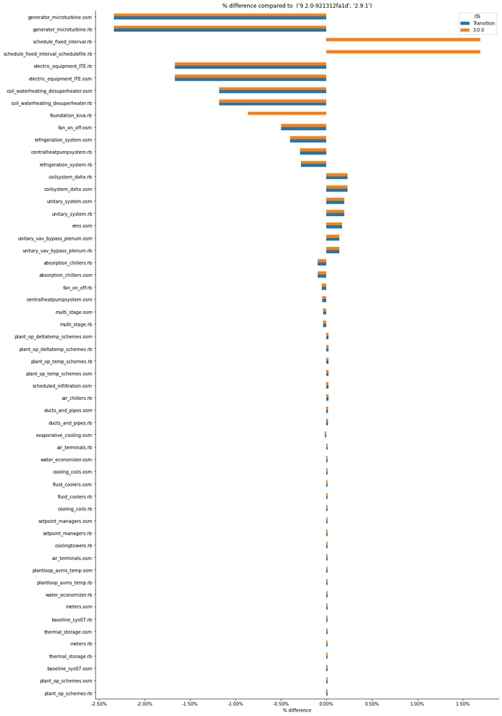

| OS | Transition | 3.0.0 |
| --- | --- | --- |
| generator_microturbine.osm | -2.34% | -2.34% |
| generator_microturbine.rb | -2.34% | -2.34% |
| schedule_fixed_interval.rb | 0.00% | 1.69% |
| schedule_fixed_interval_schedulefile.rb | 0.00% | 1.69% |
| electric_equipment_ITE.rb | -1.67% | -1.67% |
| electric_equipment_ITE.osm | -1.67% | -1.67% |
| coil_waterheating_desuperheater.osm | -1.18% | -1.18% |
| coil_waterheating_desuperheater.rb | -1.18% | -1.18% |
| foundation_kiva.rb | -0.00% | -0.86% |
| fan_on_off.osm | -0.50% | -0.50% |
| refrigeration_system.osm | -0.40% | -0.40% |
| centralheatpumpsystem.rb | -0.29% | -0.29% |
| refrigeration_system.rb | -0.28% | -0.28% |
| coilsystem_dxhx.osm | 0.23% | 0.23% |
| coilsystem_dxhx.rb | 0.23% | 0.23% |
| unitary_system.osm | 0.20% | 0.20% |
| unitary_system.rb | 0.20% | 0.20% |
| ems.osm | 0.17% | 0.17% |
| unitary_vav_bypass_plenum.osm | 0.14% | 0.14% |
| unitary_vav_bypass_plenum.rb | 0.14% | 0.14% |
| absorption_chillers.rb | -0.10% | -0.10% |
| absorption_chillers.osm | -0.10% | -0.10% |
| fan_on_off.rb | -0.05% | -0.05% |
| centralheatpumpsystem.osm | -0.05% | -0.05% |
| multi_stage.osm | -0.03% | -0.03% |
| multi_stage.rb | -0.03% | -0.03% |
| plant_op_temp_schemes.osm | 0.02% | 0.02% |
| plant_op_temp_schemes.rb | 0.02% | 0.02% |
| plant_op_deltatemp_schemes.rb | 0.02% | 0.02% |
| plant_op_deltatemp_schemes.osm | 0.02% | 0.02% |
| scheduled_infiltration.osm | 0.02% | 0.02% |
| air_chillers.rb | 0.02% | 0.02% |
| ducts_and_pipes.osm | 0.02% | 0.02% |
| ducts_and_pipes.rb | 0.02% | 0.02% |
| evaporative_cooling.osm | -0.02% | -0.02% |
| air_terminals.rb | 0.02% | 0.02% |
| water_economizer.osm | 0.01% | 0.01% |
| cooling_coils.osm | 0.01% | 0.01% |
| fluid_coolers.osm | 0.01% | 0.01% |
| fluid_coolers.rb | 0.01% | 0.01% |
| cooling_coils.rb | 0.01% | 0.01% |
| setpoint_managers.rb | 0.01% | 0.01% |
| setpoint_managers.osm | 0.01% | 0.01% |
| coolingtowers.rb | 0.01% | 0.01% |
| air_terminals.osm | 0.01% | 0.01% |
| plantloop_avms_temp.osm | 0.01% | 0.01% |
| plantloop_avms_temp.rb | 0.01% | 0.01% |
| water_economizer.rb | 0.01% | 0.01% |
| meters.osm | 0.01% | 0.01% |
| baseline_sys07.rb | 0.01% | 0.01% |
| thermal_storage.osm | 0.01% | 0.01% |
| meters.rb | 0.01% | 0.01% |
| thermal_storage.rb | 0.01% | 0.01% |
| baseline_sys07.osm | 0.01% | 0.01% |
| plant_op_schemes.osm | 0.01% | 0.01% |
| plant_op_schemes.rb | 0.01% | 0.01% |